# vbhavya_data_replication

## Data Replication:

### Table 1

```r
#creating an empty table where values can be input
table1.1 <- data.frame(matrix(NA, nrow = 6, ncol = 8))
colnames(table1.1) <- c("organisational level group size (g)", "Horton order (ω)", "sample size (n)", "ln mean <ln g>", "s.d", "geometric mean (g-bar)", "95% CI - Lower", "95% CI - upper")
table1.1[,1] <- c("individual", "family","dispersed group","aggregated group","periodic aggregation","population size")
table1.1[,2] <- 1:6
table1.1[,3] <- c("NA", 136,227,297,216,339)

#Okay, now we can start filling in this table with some summary statistics!

#filling in ln means, sd and geometric means
for (i in 1:5) {
  ln_mean <- mean(log(all_groups_dat[[i]]))
  table1.1[i+1,4] <- ln_mean
  table1.1[1,4] <- 0

  sd <- sd(log(all_groups_dat[[i]]))
  table1.1[i+1,5] <- sd
  table1.1[1,5] <- NA

  geom_mean <- exp(ln_mean)
  table1.1[i+1,6] <- geom_mean
  table1.1[1,6] <- 1
}

table1.1 #Here, we see that the values are a little bit different that the original paper. But they don't seem different enough to warrant concern, yet.
```

```
##   organisational level group size (g) Horton order (ω) sample size (n)
## 1                          individual                1              NA
## 2                              family                2             136
## 3                     dispersed group                3             227
## 4                    aggregated group                4             297
## 5                periodic aggregation                5             216
## 6                     population size                6             339
##   ln mean <ln g>       s.d geometric mean (g-bar) 95% CI - Lower 95% CI - upper
## 1       0.000000        NA               1.000000             NA             NA
## 2       1.497908 0.2266828               4.472322             NA             NA
## 3       2.749100 0.4611244              15.628552             NA             NA
## 4       3.989574 0.7136384              54.031841             NA             NA
## 5       5.105074 0.6559420             164.856221             NA             NA
## 6       6.729334 1.2517243             836.590075             NA             NA
```

```r
#Bootstrapping For CIs (ln_mean)
for (i in 1:5) {
  set.seed(1)
  ln_dat <- log(all_groups_dat[[i]]) #We will bootstrap with this data
  ln_mean <- mean(ln_dat)
  boots_ln_dat = ln_dat[sample(1:length(ln_dat), 1000, replace = TRUE)] #resampling with replacement. Creating 1000 samples
  mean_boots <- exp(mean(boots_ln_dat)) #geometric mean for bootsrapped values
  sd_boots <- sd(boots_ln_dat) #sd for bootsrapped values

  #lower - 95% CI
  lower_CI <- mean_boots - qnorm(1 - 0.05/2) * sd_boots #lower CI
  lower_CI
  table1.1[i+1,7] <- lower_CI
  table1.1[1,7] <- NA

  #upper - 95% CI
  upper_CI <- mean_boots + qnorm(1 - 0.05/2) * sd_boots #upper CI
  upper_CI
  table1.1[i+1,8] <- upper_CI
  table1.1[1,8] <- NA
}

table1.1 #The CI values actually look quite different from the values in the published table
```

```
##   organisational level group size (g) Horton order (ω) sample size (n)
## 1                          individual                1              NA
## 2                              family                2             136
## 3                     dispersed group                3             227
## 4                    aggregated group                4             297
## 5                periodic aggregation                5             216
## 6                     population size                6             339
##   ln mean <ln g>       s.d geometric mean (g-bar) 95% CI - Lower 95% CI - upper
## 1       0.000000        NA               1.000000             NA             NA
## 2       1.497908 0.2266828               4.472322       4.049207       4.925587
## 3       2.749100 0.4611244              15.628552      14.549443      16.330475
## 4       3.989574 0.7136384              54.031841      53.419674      56.183082
## 5       5.105074 0.6559420             164.856221     155.613555     158.097368
## 6       6.729334 1.2517243             836.590075     890.821012     895.716542
```

```r
#creating an empty table where values can be input
table1.2 <- data.frame(matrix(NA, nrow = 6, ncol = 8))
colnames(table1.2) <- c("Frequency, N(g)", "Horton order (ω)", "sample size (n)", "ln mean <ln N(g)>", "s.d", "geometric mean (N(g)-bar)", "95% CI - Lower", "95% CI - upper")
table1.2[,1] <- c("individual", "family","dispersed group","aggregated group","periodic aggregation","poopulation size")
table1.2[,2] <- 1:6
table1.2[,3] <- c(339, 216, 297, 227, 128, "NA")

#Okay, now we can start filling in this table with some summary statistics!

#filling in ln means, sd and geometric means
for (i in 1:5) {
  ln_mean <- mean(log(all_groups_freq[[i]]))
  table1.2[i,4] <- ln_mean
  table1.2[6,4] <- 0

  sd <- sd(log(all_groups_freq[[i]]))
  table1.2[i,5] <- sd
  table1.2[6,5] <- NA

  geom_mean <- exp(ln_mean)
  table1.2[i,6] <- geom_mean
  table1.2[6,6] <- 1
}

table1.2 #Here, we see that the values are a little bit different that the original paper. But they don't seem different enough to warrant concern, yet.
```

```
##        Frequency, N(g) Horton order (ω) sample size (n) ln mean <ln N(g)>
## 1           individual                1             339          6.729334
## 2               family                2             216          4.941434
## 3      dispersed group                3             297          3.773022
## 4     aggregated group                4             227          2.720442
## 5 periodic aggregation                5             128          1.527458
## 6     poopulation size                6              NA          0.000000
##        s.d geometric mean (N(g)-bar) 95% CI - Lower 95% CI - upper
## 1 1.251724                836.590075             NA             NA
## 2 1.208410                139.970884             NA             NA
## 3 1.147000                 43.511374             NA             NA
## 4 1.139904                 15.187035             NA             NA
## 5 1.064040                  4.606452             NA             NA
## 6       NA                  1.000000             NA             NA
```

```r
#Bootstrapping For CIs (ln_mean)
for (i in 1:5) {
  set.seed(1)
  ln_dat <- log(all_groups_freq[[i]]) #We will bootstrap with this data
  ln_mean <- mean(ln_dat)
  boots_ln_dat = ln_dat[sample(1:length(ln_dat), 1000, replace = TRUE)] #resampling with replacement. Creating 1000 samples
  mean_boots <- exp(mean(boots_ln_dat)) #geometric mean for bootsrapped values
  sd_boots <- sd(boots_ln_dat) #sd for bootsrapped values

  #lower - 95% CI
  lower_CI <- mean_boots - qnorm(1 - 0.05/2) * sd_boots #lower CI
  lower_CI
  table1.2[i,7] <- lower_CI
  table1.2[6,7] <- NA

  #upper - 95% CI
  upper_CI <- mean_boots + qnorm(1 - 0.05/2) * sd_boots #upper CI
  upper_CI
  table1.2[i,8] <- upper_CI
  table1.2[6,8] <- NA
}

table1.2 #The CI values actually look quite different from the values in the published table, but that is to be expected if we bootstrap the values.
```

```
##        Frequency, N(g) Horton order (ω) sample size (n) ln mean <ln N(g)>
## 1           individual                1             339          6.729334
## 2               family                2             216          4.941434
## 3      dispersed group                3             297          3.773022
## 4     aggregated group                4             227          2.720442
## 5 periodic aggregation                5             128          1.527458
## 6     poopulation size                6              NA          0.000000
##        s.d geometric mean (N(g)-bar) 95% CI - Lower 95% CI - upper
## 1 1.251724                836.590075     890.821012     895.716542
## 2 1.208410                139.970884     136.668812     141.271324
## 3 1.147000                 43.511374      41.801633      46.342593
## 4 1.139904                 15.187035      13.465560      18.093026
## 5 1.064040                  4.606452       2.670988       6.922304
## 6       NA                  1.000000             NA             NA
```

### Plotting Figure 1: Group sizes as a function of Horton order (Bonus?)

```r
library(ggplot2)
family <- as.data.frame(family)
colnames(family) <- "group_size"
fig1_df <- family
gr1 <- as.data.frame(gr1)
colnames(gr1) <- "group_size"
fig1_df <- rbind(fig1_df,gr1)
gr2 <- as.data.frame(gr2)
colnames(gr2) <- "group_size"
fig1_df <- rbind(fig1_df,gr2)
gr3 <- as.data.frame(gr3)
colnames(gr3) <- "group_size"
fig1_df <- rbind(fig1_df,gr3)
population <- as.data.frame(population)
colnames(population) <- "group_size"
fig1_df <- rbind(fig1_df,population)

fig1_df$Horton_Order <- NA
fig1_df$Horton_Order[1:102] <- 2
fig1_df$Horton_Order[103:329] <- 3
fig1_df$Horton_Order[330:626] <- 4
fig1_df$Horton_Order[627:842] <- 5
fig1_df$Horton_Order[843:1181] <- 6
ho1<- data.frame(1,1)
colnames(ho1) <- c("group_size","Horton_Order")
fig1_df<- rbind(fig1_df,ho1)
unique(fig1_df$Horton_Order)
```

```
## [1]  2  3  4  5  6 NA  1
```

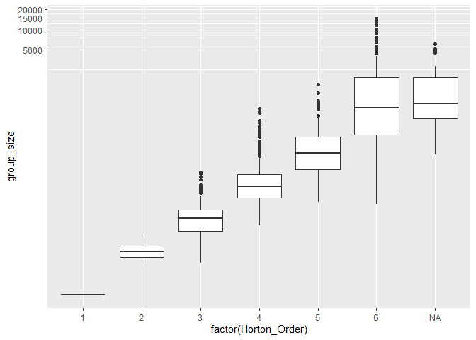

```r
fig1 <- ggplot(fig1_df,aes(factor(Horton_Order),group_size))+ coord_trans(y = "log10") +geom_boxplot()
fig1
```

```r
#NOTE:
#In Hamilton et al., 2007, they plot a box and whisker plot where the whiskers show 95% CIs around the median, and the boxes show 67% CIs. However, the only code that I could find that does that is:
#fig1 <- ggplot(fig1_df,aes(factor(Horton_Order),group_size))+ coord_trans(y = "log10")
#sd.box <- function(d) {
#return(data.frame(y = median(d), ymin=mean(d) - qnorm(1 - 0.05/2) * sd(d), ymax=mean(d) + qnorm(1 - 0.05/2) * sd(d), upper=mean(d) + qnorm(1 - 0.33/2) * sd(d), lower=mean(d) - qnorm(1 - 0.33/2) * sd(d))) }
#fig1 <- fig1 + stat_summary(fun.data = sd.box, geom="boxplot")
#fig1
#However, this code should be working, but for whatever reason, it gives an error because I haven't defined some of the aesthetics, even though it should be taking the defaults. I'm not sure how to fix this and I spent HOURS just finding this code to being with because box and whisker plots usually use quartiles.

# Source for the above code: https://github.com/tidyverse/ggplot2/issues/898
```

### Table 2: Branching Ratios and Mean Family Sizes by Continent

```r
#Making new data frames for each continent
data_continent <- cbind(dat$continent,dat$famsz)
asia <- data_continent[data_continent[,1] == "Asia",]
africa <- data_continent[data_continent[,1] == "Africa",]
n_am <- data_continent[data_continent[,1] == "North America",]
australia <- data_continent[data_continent[,1] == "Australia",]
s_am <- data_continent[data_continent[,1] == "South America",]

#combining all data frames by continents into a list that can be indexed and used in a function to calculate stats
continents_dat <- list(data_continent,asia,africa,n_am,australia,s_am)
```

```r
#skeletons of table 2
table2 <- data.frame(matrix(NA, nrow = 6, ncol = 9))
colnames(table2) <- c("sample", "sample size (n)", "Branching Ratios (B-bar)", "95% CI - Lower", "95% CI - upper", "sample size (n)", "Family Size (F-bar)","95% CI - Lower", "95% CI - upper")
table2[,1] <- c("All data", "Asia","Africa","North America","Australia","South America")

for (i in 1:6) {
  sample_size_fam <- length(na.omit(continents_dat[[i]][,2]))
  table2[i,6] <- sample_size_fam

  set.seed(1)
  ln_dat <- log(as.numeric(na.omit(continents_dat[[i]][,2]))) #We will bootstrap with this data in a few steps and use it to calculate the geometric mean
  ln_mean <- mean(ln_dat)
  geom_mean <- exp(ln_mean)
  table2[i,7] <- geom_mean #adding geometric means to column F-bar

  #bootstrapping for CIs
  boots_ln_dat = ln_dat[sample(1:length(ln_dat), 1000, replace = TRUE)] #resampling with replacement. Creating 1000 samples
  mean_boots <- exp(mean(boots_ln_dat)) #geometric mean for bootsrapped values
  sd_boots <- sd(boots_ln_dat) #sd for bootsrapped values

  #lower - 95% CI
  lower_CI <- mean_boots - qnorm(1 - 0.05/2) * sd_boots #lower CI
  lower_CI
  table2[i,8] <- lower_CI

  #upper - 95% CI
  upper_CI <- mean_boots + qnorm(1 - 0.05/2) * sd_boots #upper CI
  upper_CI
  table2[i,9] <- upper_CI
}

table2
```

```
##          sample sample size (n) Branching Ratios (B-bar) 95% CI - Lower
## 1      All data              NA                       NA             NA
## 2          Asia              NA                       NA             NA
## 3        Africa              NA                       NA             NA
## 4 North America              NA                       NA             NA
## 5     Australia              NA                       NA             NA
## 6 South America              NA                       NA             NA
##   95% CI - upper sample size (n) Family Size (F-bar) 95% CI - Lower
## 1             NA             136            4.472322       4.049207
## 2             NA              20            3.914412       3.684964
## 3             NA               9            4.369591       4.132454
## 4             NA              69            4.196642       3.847318
## 5             NA              24            6.154716       5.861359
## 6             NA              14            4.346514       3.941722
##   95% CI - upper
## 1       4.925587
## 2       4.127475
## 3       4.662099
## 4       4.571950
## 5       6.465074
## 6       4.643851
```

```r
#Because branching rations need information about the frequencies of family size (ω = 2), and for Horton order ω-1 = 1, which is frequency of individuals, let us add that data to our "data by continent" data frame

data_continent <- cbind(data_continent,dat$tlpop)
data_continent <- cbind(data_continent,dat$numfam)
data_continent <- cbind(data_continent,dat$numg1)
data_continent <- cbind(data_continent,dat$numg2)
data_continent <- cbind(data_continent,dat$numg3)

#re-making data frames for each continent, but now containing the new required information
asia <- data_continent[data_continent[,1] == "Asia",]
africa <- data_continent[data_continent[,1] == "Africa",]
n_am <- data_continent[data_continent[,1] == "North America",]
australia <- data_continent[data_continent[,1] == "Australia",]
s_am <- data_continent[data_continent[,1] == "South America",]

#combining all data frames by continents into a list that can be indexed and used in a function to calculate branching ratios and other stats
continents_dat <- list(data_continent,asia,africa,n_am,australia,s_am)
```

In order to fill the first four columns of Table 2, it will be useful to have the values for branching ratios. The easies way to get branching ratios is to run linear regressions for ln frequency of group size as a function of the Horton order. Once we get the slope ( λ) from these linear regressions, we can calculate branching ratios with this formula:

λ = lnB

```r
# In order to run a linear regression for <ln N(g)> vs Horton Order, we need to calculate <ln N(g)> values for each Horton Order in each continent. Let's create a new data frames per continent to hold these values.

#starting with all data
linear_reg_dat <- data.frame(matrix(NA, nrow = 6, ncol = 3))
colnames(linear_reg_dat) <- c("horton_order","ln_mean_freq","Continent")
linear_reg_dat[,1] <- 1:6
linear_reg_dat[,3] <- as.factor("All")

for (i in 3:7) {
  ln_dat <- log(as.numeric(na.omit(data_continent[,i])))
  ln_mean <- mean(ln_dat)
  linear_reg_dat[i-2,2] <- ln_mean
  linear_reg_dat[6,2] <- 0
}

#For Asia
linear_reg_asia <- data.frame(matrix(NA, nrow = 6, ncol = 3))
colnames(linear_reg_asia) <- c("horton_order","ln_mean_freq","Continent")
linear_reg_asia[,1] <- 1:6
linear_reg_asia[,3] <- as.factor("Asia")

for (i in 3:7) {
  ln_dat <- log(as.numeric(na.omit(asia[,i])))
  ln_mean <- mean(ln_dat)
  linear_reg_asia[i-2,2] <- ln_mean
  linear_reg_asia[6,2] <- 0
}

linear_reg_dat1 <- rbind(linear_reg_dat,linear_reg_asia)

#repeating the same for Africa
linear_reg_africa <- data.frame(matrix(NA, nrow = 6, ncol = 3))
colnames(linear_reg_africa) <- c("horton_order","ln_mean_freq","Continent")
linear_reg_africa[,1] <- 1:6
linear_reg_africa[,3] <- as.factor("Africa")

for (i in 3:7) {
  ln_dat <- log(as.numeric(na.omit(africa[,i])))
  ln_mean <- mean(ln_dat)
  linear_reg_africa[i-2,2] <- ln_mean
  linear_reg_africa[6,2] <- 0
}
linear_reg_dat1 <- rbind(linear_reg_dat1,linear_reg_africa)

#repeating the same for North America
linear_reg_nam <- data.frame(matrix(NA, nrow = 6, ncol = 3))
colnames(linear_reg_nam) <- c("horton_order","ln_mean_freq","Continent")
linear_reg_nam[,1] <- 1:6
linear_reg_nam[,3] <- as.factor("North America")

for (i in 3:7) {
  ln_dat <- log(as.numeric(na.omit(n_am[,i])))
  ln_mean <- mean(ln_dat)
  linear_reg_nam[i-2,2] <- ln_mean
  linear_reg_nam[6,2] <- 0
}
linear_reg_dat1 <- rbind(linear_reg_dat1,linear_reg_nam)

#repeating the same for Australia
linear_reg_aus <- data.frame(matrix(NA, nrow = 6, ncol = 3))
colnames(linear_reg_aus) <- c("horton_order","ln_mean_freq","Continent")
linear_reg_aus[,1] <- 1:6
linear_reg_aus[,3] <- as.factor("Australia")

for (i in 3:7) {
  ln_dat <- log(as.numeric(na.omit(australia[,i])))
  ln_mean <- mean(ln_dat)
  linear_reg_aus[i-2,2] <- ln_mean
  linear_reg_aus[6,2] <- 0
}

linear_reg_dat1 <- rbind(linear_reg_dat1,linear_reg_aus)

#repeating the same for South America
linear_reg_sam <- data.frame(matrix(NA, nrow = 6, ncol = 3))
colnames(linear_reg_sam) <- c("horton_order","ln_mean_freq","Continent")
linear_reg_sam[,1] <- 1:6
linear_reg_sam[,3] <- as.factor("South America")

for (i in 3:7) {
  ln_dat <- log(as.numeric(na.omit(s_am[,i])))
  ln_mean <- mean(ln_dat)
  linear_reg_sam[i-2,2] <- ln_mean
  linear_reg_sam[6,2] <- 0
}

linear_reg_dat1 <- rbind(linear_reg_dat,linear_reg_sam)
```

```r
#Running linear regressions

#For all continents
linear_model <- lm(formula = ln_mean_freq ~ horton_order, data= linear_reg_dat)
summary(linear_model)
```

```
##
## Call:
## lm(formula = ln_mean_freq ~ horton_order, data = linear_reg_dat)
##
## Residuals:
##        1        2        3        4        5        6
##  0.23730 -0.26656 -0.15094  0.08051  0.17156 -0.07186
##
## Coefficients:
##              Estimate Std. Error t value Pr(>|t|)
## (Intercept)   7.77607    0.20355   38.20 2.80e-06 ***
## horton_order -1.28403    0.05227  -24.57 1.63e-05 ***
## ---
## Signif. codes:  0 '***' 0.001 '**' 0.01 '*' 0.05 '.' 0.1 ' ' 1
##
## Residual standard error: 0.2187 on 4 degrees of freedom
## Multiple R-squared:  0.9934, Adjusted R-squared:  0.9918
## F-statistic: 603.5 on 1 and 4 DF,  p-value: 1.629e-05
```

```r
# The equation obtained is Y = 7.77607 - 1.28403x, r-squared = 0.9934

exp(1.28) # since slope is λ, B = exp(slope)
```

```
## [1] 3.59664
```

```r
#For Asia
linear_model <- lm(formula = ln_mean_freq ~ horton_order, data= linear_reg_asia)
summary(linear_model)
```

```
##
## Call:
## lm(formula = ln_mean_freq ~ horton_order, data = linear_reg_asia)
##
## Residuals:
##         1         2         3         4         5         6
##  0.143051 -0.157872 -0.162186  0.007968  0.386853 -0.217815
##
## Coefficients:
##              Estimate Std. Error t value Pr(>|t|)
## (Intercept)   7.35645    0.24135   30.48 6.90e-06 ***
## horton_order -1.18977    0.06197  -19.20 4.34e-05 ***
## ---
## Signif. codes:  0 '***' 0.001 '**' 0.01 '*' 0.05 '.' 0.1 ' ' 1
##
## Residual standard error: 0.2593 on 4 degrees of freedom
## Multiple R-squared:  0.9893, Adjusted R-squared:  0.9866
## F-statistic: 368.6 on 1 and 4 DF,  p-value: 4.338e-05
```

```r
# The equation obtained is Y = 7.35645 - 1.18977x, r-squared = 0.9893

exp(1.18977) # since slope is λ, B = exp(slope)
```

```
## [1] 3.286325
```

```r
#For Africa
linear_model <- lm(formula = ln_mean_freq ~ horton_order, data= linear_reg_africa)
summary(linear_model)
```

```
##
## Call:
## lm(formula = ln_mean_freq ~ horton_order, data = linear_reg_africa)
##
## Residuals:
##        1        2        3        4        5        6
## -0.00559 -0.22539  0.04470  0.15310  0.48923 -0.45604
##
## Coefficients:
##              Estimate Std. Error t value Pr(>|t|)
## (Intercept)   7.79111    0.33681   23.13 2.07e-05 ***
## horton_order -1.22251    0.08649  -14.13 0.000145 ***
## ---
## Signif. codes:  0 '***' 0.001 '**' 0.01 '*' 0.05 '.' 0.1 ' ' 1
##
## Residual standard error: 0.3618 on 4 degrees of freedom
## Multiple R-squared:  0.9804, Adjusted R-squared:  0.9755
## F-statistic: 199.8 on 1 and 4 DF,  p-value: 0.0001454
```

```r
# The equation obtained is Y = 7.79111 - 1.22251x, r-squared = 0.9804

exp(1.22251) # since slope is λ, B = exp(slope)
```

```
## [1] 3.3957
```

```r
#For North America
linear_model <- lm(formula = ln_mean_freq ~ horton_order, data= linear_reg_nam)
summary(linear_model)
```

```
##
## Call:
## lm(formula = ln_mean_freq ~ horton_order, data = linear_reg_nam)
##
## Residuals:
##        1        2        3        4        5        6
##  0.19988 -0.14370 -0.22495  0.03818  0.17393 -0.04333
##
## Coefficients:
##              Estimate Std. Error t value Pr(>|t|)
## (Intercept)   8.09601    0.17712   45.71 1.37e-06 ***
## horton_order -1.34211    0.04548  -29.51 7.85e-06 ***
## ---
## Signif. codes:  0 '***' 0.001 '**' 0.01 '*' 0.05 '.' 0.1 ' ' 1
##
## Residual standard error: 0.1903 on 4 degrees of freedom
## Multiple R-squared:  0.9954, Adjusted R-squared:  0.9943
## F-statistic: 870.8 on 1 and 4 DF,  p-value: 7.852e-06
```

```r
# The equation obtained is Y = 8.09601 - 1.34211x, r-squared = 0.9954

exp(1.34211) # since slope is λ, B = exp(slope)
```

```
## [1] 3.82711
```

```r
#For Australia
linear_model <- lm(formula = ln_mean_freq ~ horton_order, data= linear_reg_aus)
summary(linear_model)
```

```
##
## Call:
## lm(formula = ln_mean_freq ~ horton_order, data = linear_reg_aus)
##
## Residuals:
##        1        2        3        4        5        6
##  0.20603 -0.42812  0.13484  0.22713 -0.17647  0.03658
##
## Coefficients:
##              Estimate Std. Error t value Pr(>|t|)
## (Intercept)   7.31263    0.26658   27.43 1.05e-05 ***
## horton_order -1.22487    0.06845  -17.89 5.73e-05 ***
## ---
## Signif. codes:  0 '***' 0.001 '**' 0.01 '*' 0.05 '.' 0.1 ' ' 1
##
## Residual standard error: 0.2863 on 4 degrees of freedom
## Multiple R-squared:  0.9877, Adjusted R-squared:  0.9846
## F-statistic: 320.2 on 1 and 4 DF,  p-value: 5.732e-05
```

```r
# The equation obtained is Y = 7.31263 - 1.22487x, r-squared = 0.9877

exp(1.22487) # since slope is λ, B = exp(slope)
```

```
## [1] 3.403724
```

```r
#For South America
linear_model <- lm(formula = ln_mean_freq ~ horton_order, data= linear_reg_sam)
summary(linear_model)
```

```
##
## Call:
## lm(formula = ln_mean_freq ~ horton_order, data = linear_reg_sam)
##
## Residuals:
##       1       2       3       4       5       6
##  0.5201 -0.3579 -0.4300 -0.1323  0.3854  0.0146
##
## Coefficients:
##              Estimate Std. Error t value Pr(>|t|)
## (Intercept)    6.9266     0.4031   17.18 6.73e-05 ***
## horton_order  -1.1569     0.1035  -11.18 0.000365 ***
## ---
## Signif. codes:  0 '***' 0.001 '**' 0.01 '*' 0.05 '.' 0.1 ' ' 1
##
## Residual standard error: 0.4329 on 4 degrees of freedom
## Multiple R-squared:  0.969,  Adjusted R-squared:  0.9612
## F-statistic: 124.9 on 1 and 4 DF,  p-value: 0.0003646
```

```r
# The equation obtained is Y = 6.9266 - 1.1569x, r-squared = 0.969

exp(1.1569) # since slope is λ, B = exp(slope)
```

```
## [1] 3.18006
```

[figure not shown]

```r
#Plotting Figure 2
#we also want to add the equations and r-squared values to the graphs, we'll do that using the package gridExtra
library(gridExtra)
library(grid)
library(ggplot2)
fig2 <- ggplot(linear_reg_dat1, aes(horton_order,ln_mean_freq)) + geom_point() +
  facet_wrap(~ Continent, ncol=3)+
  geom_errorbar(aes(ymin = ln_mean_freq-sd,ymax = ln_mean_freq+sd)) + #error bars as described for fig 2
  geom_smooth(method="lm") #figure 2, with everything except the equations (95% CI, and linear regression line)

grid.newpage()
vpa_ <- viewport(width = 1, height = 1)
print(fig2, vp = vpa_)
grid.text("Y = 7.77607 - 1.28403x", x=0.25, y=0.9,gp = gpar(fontsize = 8))
grid.text("r-squared = 0.9934", x=0.25, y=0.85,gp = gpar(fontsize = 8))
grid.text("Y = 7.35645 - 1.18977x", x=0.55, y=0.9,gp = gpar(fontsize = 8))
grid.text("r-squared = 0.9934", x=0.55, y=0.85,gp = gpar(fontsize = 8))
grid.text("Y = 7.79111 - 1.22251x", x=0.85, y=0.9,gp = gpar(fontsize = 8))
grid.text("r-squared = 0.9804", x=0.85, y=0.85,gp = gpar(fontsize = 8))
grid.text("Y = 8.09601 - 1.34211x", x=0.25, y=0.40,gp = gpar(fontsize = 8))
grid.text("r-squared = 0.9954", x=0.25, y=0.38,gp = gpar(fontsize = 8))
grid.text("Y = 7.31263 - 1.22487x", x=0.55, y=0.40,gp = gpar(fontsize = 8))
grid.text("r-squared = 0.9877", x=0.55, y=0.38,gp = gpar(fontsize = 8))
grid.text("Y = 6.9266 - 1.1569x", x=0.85, y=0.40,gp = gpar(fontsize = 8))
grid.text("r-squared = 0.969", x=0.85, y=0.38,gp = gpar(fontsize = 8))
```

```r
#Note: When Knit, the Plots don't show up properly. I am adding another figure that I had previously gotten using THE EXACT SAME CODE. No cheating, I promise.
```

[output not shown]

[figure not shown]

But, the branching ratios have been calculated using a linear regression analysis. All the values range from 3.18 to 3.82, which show that all branchings are self-similar. To calculate more accurate branching, however, we can separately calculate
$$B = \bar{N}(g_i^a)/\bar{N}(g_i^ω)$$

a = ω -1

Then, the mean of this for each population gives a more accurate values for branching ratios

```r
#filling up the first four columns of table 2
for (i in 1:6) {

  sample_size_fam <- length(na.omit(continents_dat[[i]][,3]))
  table2[i,2] <- sample_size_fam

linear_reg_dat$geom_mean <- exp(linear_reg_dat$ln_mean_freq) #adding geometric means
#doing this for all continents
linear_reg_asia$geom_mean <- exp(linear_reg_asia$ln_mean_freq)
linear_reg_africa$geom_mean <- exp(linear_reg_africa$ln_mean_freq)
linear_reg_nam$geom_mean <- exp(linear_reg_nam$ln_mean_freq)
linear_reg_aus$geom_mean <- exp(linear_reg_aus$ln_mean_freq)
linear_reg_sam$geom_mean <- exp(linear_reg_sam$ln_mean_freq)

linear_reg_list <- list(linear_reg_dat$geom_mean,linear_reg_asia$geom_mean,linear_reg_africa$geom_mean,linear_reg_nam$geom_mean,linear_reg_aus$geom_mean,linear_reg_sam$geom_mean)

for (i in 1:6) {
  data <- linear_reg_list[[i]]
    a <- data[1]/data[2]
    b <- data[2]/data[3]
    c <- data[3]/data[4]
    d <- data[4]/data[5]
    e <- data[5]/data[6]
    mean_branchrat <- (a+b+c+d+e)/5
    table2[i,3] <- mean_branchrat

    for_boots <- c(a,b,c,d,e)

    set.seed(100)
    boots_data = for_boots[sample(1:length(for_boots), 1000, replace = TRUE)] #re-sampling with replacement. Creating 1000 samples
   mean_boots <- mean(boots_data) #mean for bootsrapped values
   sd_boots <- sd(boots_data) #sd for bootsrapped values

  #lower - 95% CI
  lower_CI <- mean_boots - qnorm(1 - 0.05/2) * sd_boots #lower CI
  lower_CI
  table2[i,4] <- lower_CI

  #upper - 95% CI
  upper_CI <- mean_boots + qnorm(1 - 0.05/2) * sd_boots #upper CI
  upper_CI
  table2[i,5] <- upper_CI
}}

table2
```

```
##          sample sample size (n) Branching Ratios (B-bar) 95% CI - Lower
## 1      All data             339                 3.992432     1.72328558
## 2          Asia              28                 3.755772     1.11544955
## 3        Africa              20                 4.206903    -0.39933745
## 4 North America             215                 4.117220     2.34526134
## 5     Australia              56                 3.861248     0.65013327
## 6 South America              20                 3.986528    -0.06374022
##   95% CI - upper sample size (n) Family Size (F-bar) 95% CI - Lower
## 1       6.262527             136            4.472322       4.049207
## 2       6.385569              20            3.914412       3.684964
## 3       8.806193               9            4.369591       4.132454
## 4       5.879965              69            4.196642       3.847318
## 5       7.099319              24            6.154716       5.861359
## 6       8.030455              14            4.346514       3.941722
##   95% CI - upper
## 1       4.925587
## 2       4.127475
## 3       4.662099
## 4       4.571950
## 5       6.465074
## 6       4.643851
```

### Challenges Faced:

1. This was a pretty hard paper to replicate (which I didn’t expect). It was highly theoretical and in spite of the authors doing a decent job of explaining their methodology concisely, I felt that the theoretical nature of the paper made it hard for me to track down exactly what was happening.
2. There was no documentation about which samples were removed, and if they were. But the sample sizes didn’t end up matching.
3. I had issues with some code. The plots didn’t knit properly even though the same exact code ran fine when I did it in a R script to check my code.

Overall, it was stressful, but gratifying.

### Reference:

Binford, L. R. (2001). Constructing Frames of Reference: An Analytical Method for Archaeological Theory Building Using Ethnographic and Environmental Data Sets. University of California Press.

Hamilton, M. J., Milne, B. T., Walker, R. S., Burger, O., & Brown, J. H. (2007). The complex structure of hunter–gatherer social networks. Proceedings of the Royal Society B: Biological Sciences, 274(1622), 2195–2203. https://doi.org/10.1098/rspb.2007.0564